# Male vs. Female Prison Populations: How have they changed with incarceration rates in the U.S.?

Stephanie Liu

2022-11-21

[figure not shown]

## Abstract

This project will be looking over trends in incarceration rates in the U.S. Five different figures and charts will be used to analyze the any changes in incarceration trends. Furthermore, the figures and charts will be used to reveal any potential inequalities found in the incarceration trends.

## Introduction

This project was created to reveal potential inequalities found in incarceration rates across the United States. Many of these inequities are a result of many different factors, such as the issues that come with racism and sexism within our society. This data could impact the people who identify as certain groups that are discriminated against, people who identify as a certain gender or race, as well as those who are currently incarcerated. This data could also be used by researchers and journalists who want to use this data to help spread awareness about certain issues surrounding incarceration rates in the U.S. The questions that I will be answering in this report are:

- How have incarceration rates changed in the United States over time?
- What is the difference between the number of men and the number of women in jail?
- What is the ratio of the male and female jail populations?

## Growth of the U.S. Prison Population

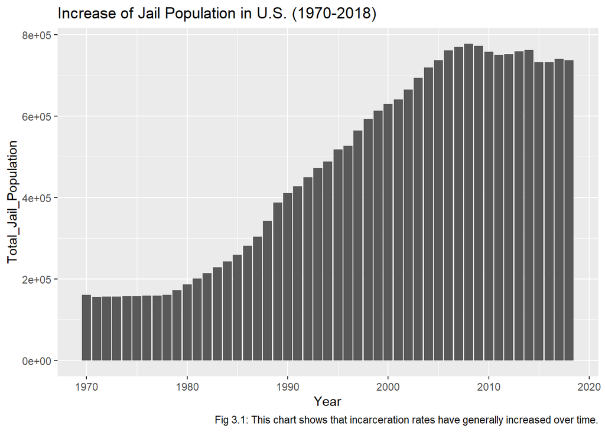

In this chart, we can see that incarceration rates in the U.S. have generally increased over time. Incarceration rates seemed to have peaked sometime between the years 2000 and 2010, and incarceration rates were at the lowest sometime between the years 1970 and 1980. This increase may have been the result of various factors, such as an overall increase in the US population.

## Growth of Prison Population by State

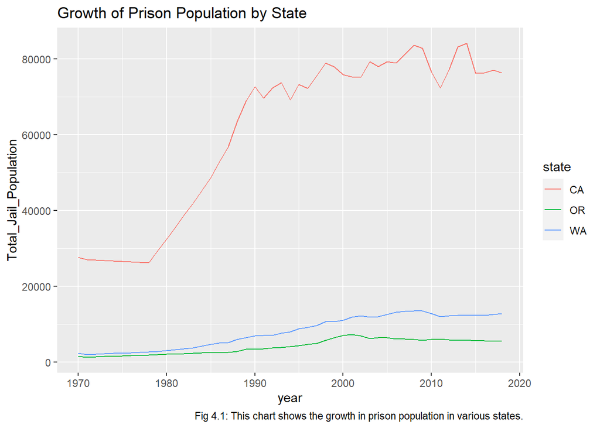

## Section 5: Jail Population by Gender

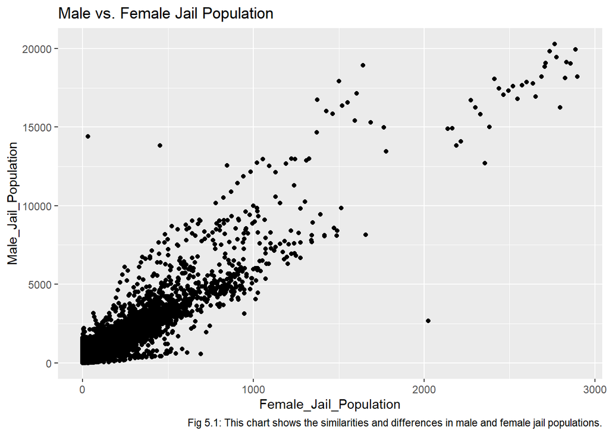

## Section 6: Distribution of Jail Population by Gender

[figure not shown]

[figure not shown]